# Flight of the Conchords: A Network Graph

### Dr. Steve McDonald

“Flight of the Conchords” was an American sitcom about a New Zealand folk-rock band living in New York City. Below I will generate a network graph from the friendships shown in season 2 episode 4, “Murray Takes it to the Next Level.”

To begin with, I will load the igraph package into the library

```r
library(igraph)
```

## Create a graph object from an edgelist

An edgelist shows a set of relationships between pairs of nodes in a network. The graph function creates an igraph object that can be plotted later. Each line shows an edge or line between two friends.

But why does the last line show a tie between Greg and himself? I include this because Greg is actually an isolate with no friends. (Sorry, Greg.) If I don’t include this self-tie (called a “loop”), then Greg won’t be included in the network.

```r
conchords <- graph(edges=c("Brett","Jemaine",
                           "Brett","Murray",
                           "Jemaine","Murray",
                           "Murray","Jim",
                           "Greg","Greg"), directed=F )
```

## Degree distribution

Degree refers to the number of connections that each node has with other nodes. What does the degree distribution look like?

```r
degree(conchords)
```

```
##   Brett Jemaine  Murray     Jim    Greg
##       2       2       3       1       2
```

As you can see, the person with the most friendships is Murray with a degree of 3.

Greg’s degree is inaccurate because we brought him into the network as a loop. To get rid of the loop, we can use the simplify command with the remove.loops option set to TRUE.

```r
conchords <- simplify(conchords,
                      remove.loops = TRUE)
```

## Graph the conchords network

Now it is time to graph the network. First, I remove the margins from the plot area. Then I specify some features of the graph within the plot function. I set the size of the nodes (also known as “vertices”), the size of the names for each node, and the color of each node.

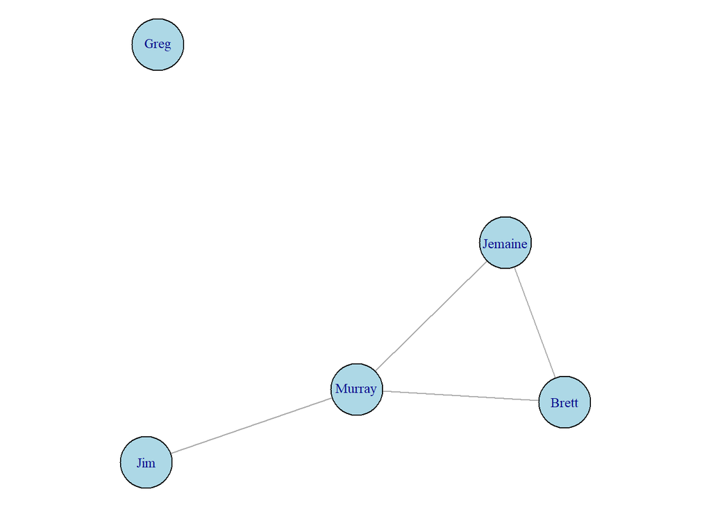

```r
par(mar=c(0,0,0,0))
plot(conchords,
     vertex.size=25,
     vertex.label.cex=.8,
     vertex.color="lightblue")
```

## Picture of the Conchords

Finally, here’s a picture of the guys from the episode!

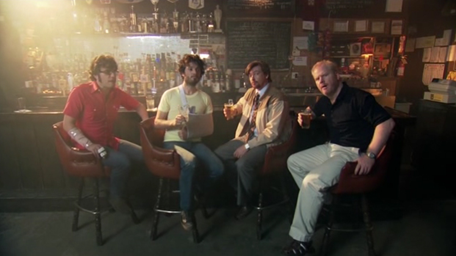

Flight of the Conchords friends [Not shown: Greg]

You can learn more about the show [here](https://www.imdb.com/title/tt0863046/).